# Homework 1

PSTAT 131

2022-09-28

## Machine Learning Main Ideas

Please answer the following questions. Be sure that your solutions are clearly marked and that your document is neatly formatted.

You don’t have to rephrase everything in your own words, but if you quote directly, you should cite whatever materials you use (this can be as simple as “from the lecture/page # of book”).

### Question 1:

Define supervised and unsupervised learning. What are the difference(s) between them?

#### Answer:

Both supervised and unsupervised learning are machine learning approaches to classify or predict data. Supervised learning uses labeled data (both input and output data), so the models can be checked for accuracy. Unsupervised learning does not require labeled data, but rather outputs a result (classifications, clusters, etc) that usually needs to be validated by a data scientist.

### Question 2:

Explain the difference between a regression model and a classification model, specifically in the context of machine learning.

#### Answer:

A regression model predicts a specific numeric value given labeled input data. Classification models do not necessarily predict a numeric value, but rather assigns the inputted data into one of the predetermined classes.

### Question 3:

Name two commonly used metrics for regression ML problems. Name two commonly used metrics for classification ML problems.

#### Answer:

R-squared and the Mean Squared Error are commonly used for regression models. Accuracy and Precision are commonly used metrics for classification models.

### Question 4:

As discussed, statistical models can be used for different purposes. These purposes can generally be classified into the following three categories. Provide a brief description of each.

Descriptive models: Take into account all features equally before classifying the input into a category. Usually uses unsupervised learning (https://en.proft.me/2015/12/24/types-machine-learning-algorithms/).

Inferential models: Determines a relationship between input and output values. Similar to predictive models (below), but tends to focus less on output values and more of how input affects output. Ex: for every inch taller a person is, the chance of making the NBA increases by 0.1%.

Predictive models: Uses input values to determine an output value. Because it needs to “know” how to use the input values before making a prediction, these models tend to use supervised learning.

### Question 5:

Predictive models are frequently used in machine learning, and they can usually be described as either mechanistic or empirically-driven. Answer the following questions.

Define mechanistic. Define empirically-driven. How do these model types differ? How are they similar?

In general, is a mechanistic or empirically-driven model easier to understand? Explain your choice.

Describe how the bias-variance tradeoff is related to the use of mechanistic or empirically-driven models.

#### Answer:

Mechanistic models use theories or formulas to predict results. Empirically driven models tend to use experimentation or trials to predict results. Although both methods are similar in that they predict some type of result and are susceptible to overfitting, mechanistic model types are more ‘academic’-based and empirical models are observation based.

Both models are relatively easy to understand, but empirically-driven models seem easier to explain. Ex: You can create multiple clusters of movies on Netflix based on observing what people watch, and use this “model” to suggest movies to other people who have watched movies within each cluster.

### Question 6:

A political candidate’s campaign has collected some detailed voter history data from their constituents. The campaign is interested in two questions:

Given a voter’s profile/data, how likely is it that they will vote in favor of the candidate? **Predictive: predicting an output (probability of voting for the candidate) given labeled input data (voter’s profile)**

How would a voter’s likelihood of support for the candidate change if they had personal contact with the candidate? **Inferential: not much “hard data” to work with, more of a guess of change in support given personal contact**

Classify each question as either predictive or inferential. Explain your reasoning for each.

## Exploratory Data Analysis

This section will ask you to complete several exercises. For this homework assignment, we’ll be working with the mpg data set that is loaded when you load the tidyverse. Make sure you load the tidyverse and any other packages you need.

Exploratory data analysis (or EDA) is not based on a specific set of rules or formulas. It is more of a state of curiosity about data. It’s an iterative process of:

generating questions about data visualize and transform your data as necessary to get answers use what you learned to generate more questions A couple questions are always useful when you start out. These are “what variation occurs within the variables,” and “what covariation occurs between the variables.”

You should use the tidyverse and ggplot2 for these exercises.

### Exercise 1:

We are interested in highway miles per gallon, or the hwy variable. Create a histogram of this variable. Describe what you see/learn.

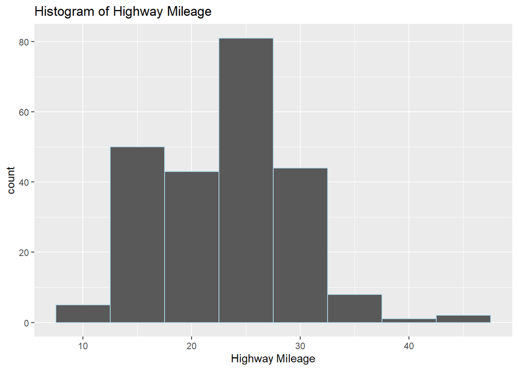

```r
library(tidyverse)
library(ggplot2)
ggplot(mpg, aes(x=hwy)) +
  geom_histogram(color='light blue', binwidth=5) +
  labs(title="Histogram of Highway Mileage", x="Highway Mileage")
```

**It seems like the vast majority of cars get an average 15 to 30 miles MPG on the highway. There are a few outliers that get over 35 mpg, which are likely hybrid cars such as a Prius.**

### Exercise 2:

Create a scatterplot. Put hwy on the x-axis and city on the y-axis. Describe what you notice. Is there a relationship between hwy and cty? What does this mean?

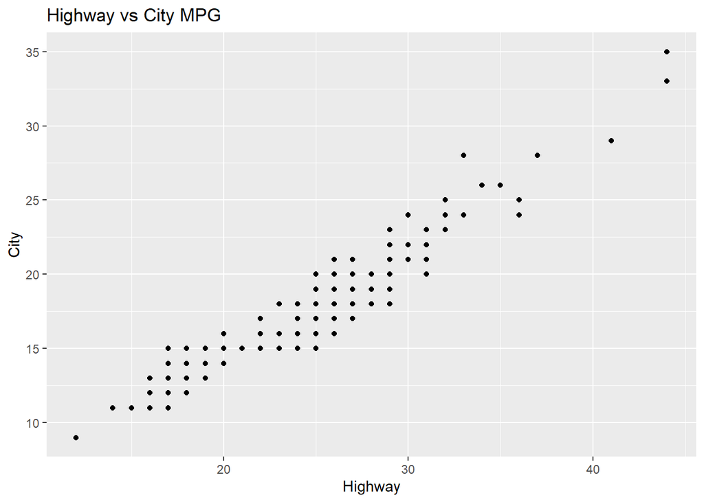

```r
ggplot(mpg, aes(x=hwy, y=cty)) +
  geom_point() +
  labs(title="Highway vs City MPG", x="Highway", y = "City")
```

**There seems to be a linear relationship between the city and highway mileage for each car. Even the outliers mentioned above for the highway MPG seem to follow this relationship.**

### Exercise 3:

Make a bar plot of manufacturer. Flip it so that the manufacturers are on the y-axis. Order the bars by height. Which manufacturer produced the most cars? Which produced the least?

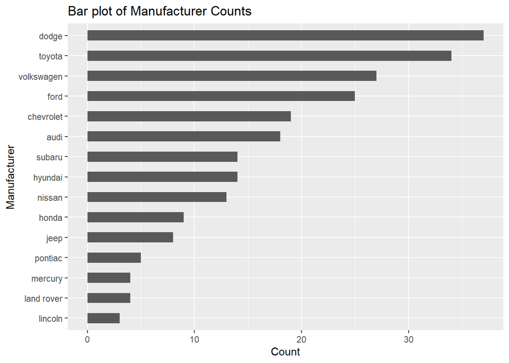

```r
library(dplyr)

count(mpg, manufacturer) %>%
      ggplot(aes(x = reorder(manufacturer, n), y = n)) +
      geom_bar(width=0.5, stat='identity')+
      coord_flip() +
      labs(title="Bar plot of Manufacturer Counts", x='Manufacturer', y='Count')
```

**Dodge produced the most cars, and Lincoln produced the least.**

### Exercise 4:

Make a box plot of hwy, grouped by cyl. Do you see a pattern? If so, what?

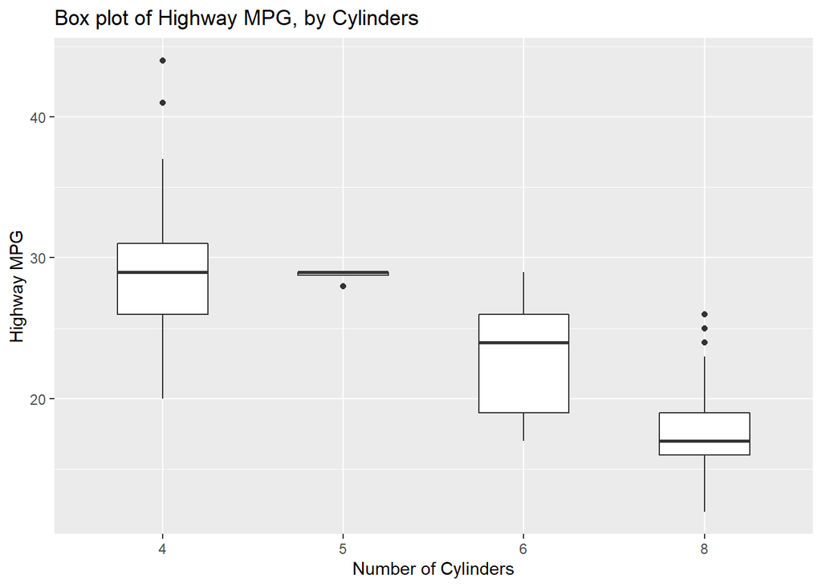

```r
mpg2 <- mpg
mpg2$cyl <- as.factor(mpg2$cyl)

ggplot(mpg2, aes(x=cyl, y=hwy)) +
  geom_boxplot(width=0.5) +
  labs(title='Box plot of Highway MPG, by Cylinders', x='Number of Cylinders', y='Highway MPG')
```

**It seems as the number of cylinders increases, the average highway mpg decreases.**

### Exercise 5:

Use the corrplot package to make a lower triangle correlation matrix of the mpg dataset. (Hint: You can find information on the package here.)

Which variables are positively or negatively correlated with which others? Do these relationships make sense to you? Are there any that surprise you?

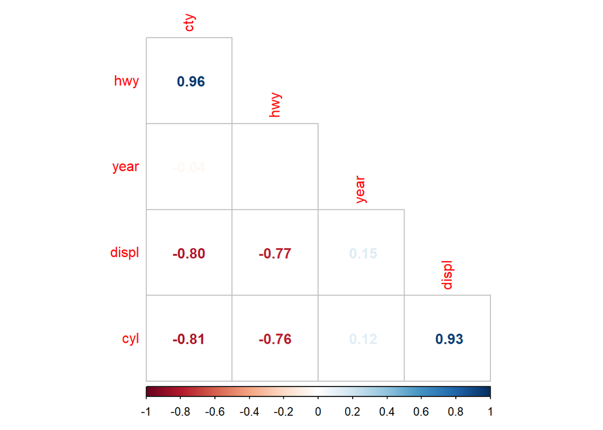

```r
library(corrplot)
library(Hmisc)
mpg4 <- select_if(mpg, is.numeric)
mpg4 <- cor(mpg4)
corrplot(mpg4, method = 'number', order = 'FPC', type = 'lower', diag = FALSE)
```

**As expected from the scatterplot above, highway and city mpg are positively correlated. Displacement and cylinders are both negatively correlated to both highway and city mileage, so it makes sense that they’re (displacement and cylinders) are positively correlated. Cylinder count having a negative correlation with mpg makes sense, as those cars will use more power and therefore use more gas. I’m surprised that the year of the car doesn’t seem to have much influence on the mileage.**

Note: I spent slightly less than a couple hours on this problem and couldn’t figure out how to get the categorical variables into this correlation plot in a nice, clean way (manufacturer, model, etc.). The web pages I looked at included the following, among many others:  
https://stackoverflow.com/questions/21140798/error-using-corrplot  
https://stats.stackexchange.com/questions/119835/correlation-between-a-nominal-iv-and-a-continuous-dv-variable/124618#124618  
https://stats.stackexchange.com/questions/108007/correlations-with-unordered-categorical-variables  
https://en.wikipedia.org/wiki/Analysis_of_variance  
https://stackoverflow.com/questions/52554336/plot-the-equivalent-of-correlation-matrix-for-factors-categorical-data-and-mi  
https://rpubs.com/hoanganhngo610/558925